# Perspectives on Computational Modeling: Problem Set #9

Xingyun Wu

2017/3/15

## Part 1: Attitudes towards feminists

### 1. Import and split data

The data has been imported and spitted as required.

### 2. KNN models

The response variable of my model is `feminist`, and the predictors I choose are `female`, `age`, `educ` and `income`. The plot below shows the relation between test MSE for KNN models and values of k.

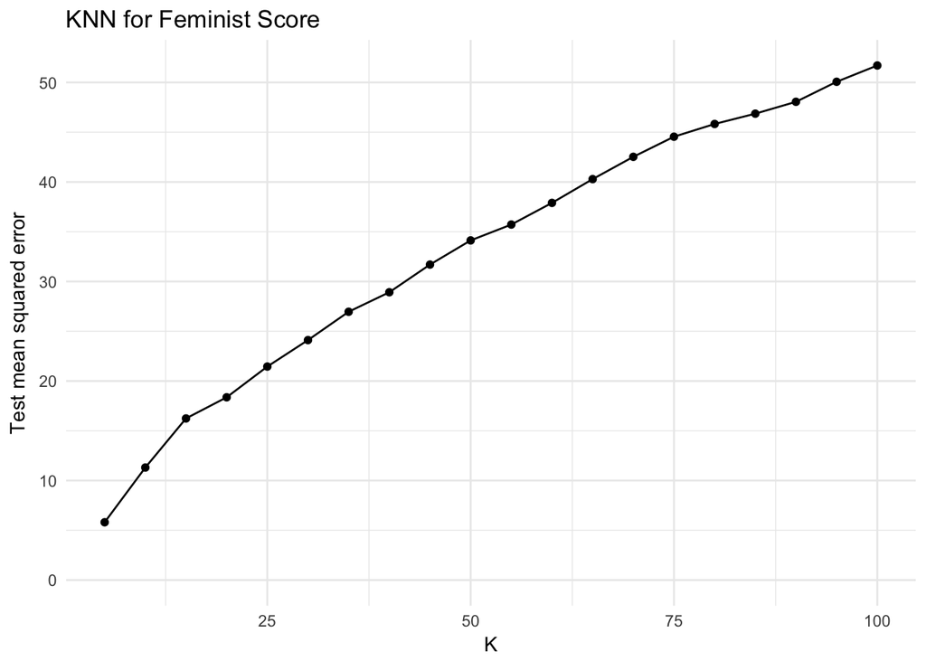

```
## [1] 5.81
```

According to the plot, the test MSE increases with the increase of k for KNN models. Thus, it would be the model with `k = 5` that produces the lowest test MSE, which is 5.81.

### 3. Weighted KNN models

Settings of response variable and predictors are the same as the previous question. The plot below shows the relationship between the test MSE and k of weighted KNN models.

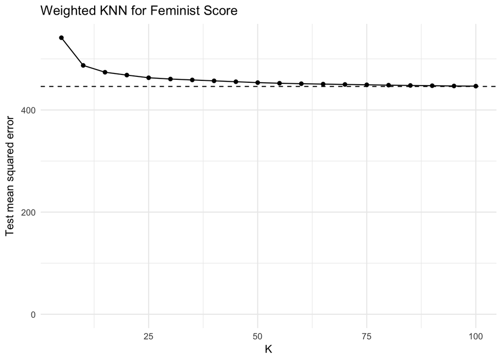

```
## [1] 447
```

The plot shows that the test MSE decreases with the increase of k. The lowest test MSE is 447, which occurs when `k = 100`. However, both the plot and the lowest test MSE shows that the weighted KNN models does not perform well. Their lowest test MSE is much higher than the lowest test MSE for the previous KNN models. In addition, the plot shows that their test MSE is not improved, compared to the test MSE of the OLS model.

### 4. Comparison

As is required, I calculated the test MSE for the equivalent linear regression, decision tree, boosting, and random forest methods using the same combination of varialbes as before. And compare them to the test MSE for the best KNN/wKNN models. Note that the model with boosting method is with `depth = 1`.

```
## The test MSE of the best KNN model is:  5.81
```

```
## The test MSE of the best wKNN model is:  447
```

```
## The test MSE of equivalent linear regression model is:  446
```

```
## The test MSE of equivalent decision tree is:  452
```

```
## The test MSE of equivalent boosting method is:  444
```

```
## The test MSE of equivalent random forest is:  447
```

According to the comparison above, the KNN model performs best, with much lower test MSE. And the other five models have very similar test MSEs. Note that the weighted KNN model does not perform better than the other methods. It seems like the traditional KNN model beats the other five models in this case. The traditional KNN model performs better because it relaxes assumptions about the functional form of $f$. It uses the data to estimate $f$ directly, so it could get close to the data points and avoid overcomplexity. But it depends on data whether traditional KNN model or weighted KNN model would perform better.

## Part 2: Voter turnout and depression

### 1. Import and split data

The `mental_health` data is imported and splitted as required.

### 2. Test error rate for KNN models

The response variable in this part is `vote96`, and the predictors are `mhealth_sum`, `age`, `educ` and `inc10`. I choose these predictors because they represent important features of individuals. `mhealth_sum` represents mental state that would influence behavior. `age` is a very important demographic feature. `educ` and `inc10` are good explanatory variables to locate individuals’ social status.

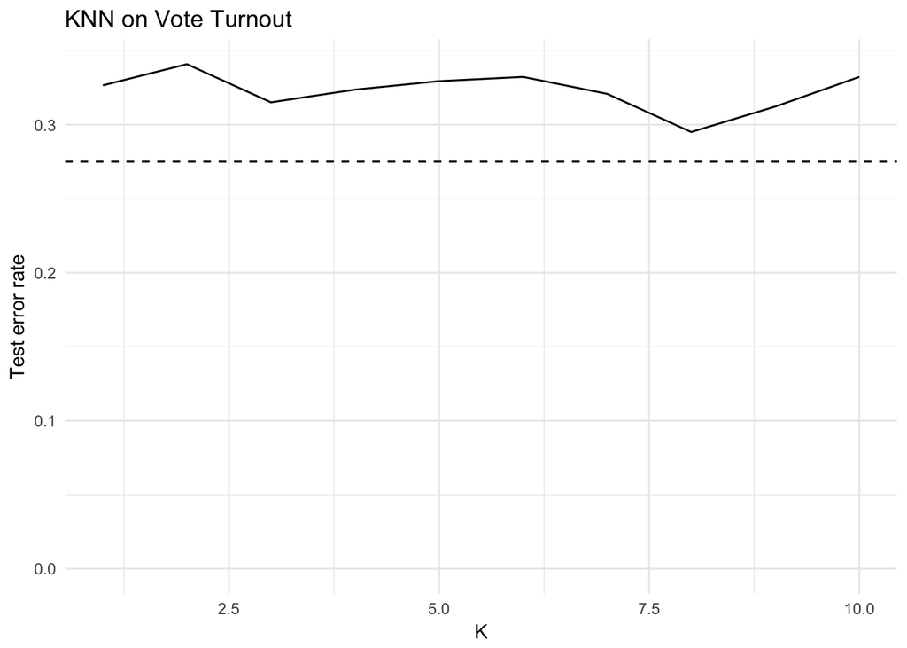

```
## [1] 0.295
```

According to the plot, the KNN model does not perform better than GLM. The model with `k = 8` produces the lowest test MSE, which is 0.295.

### 3. Weighted KNN models

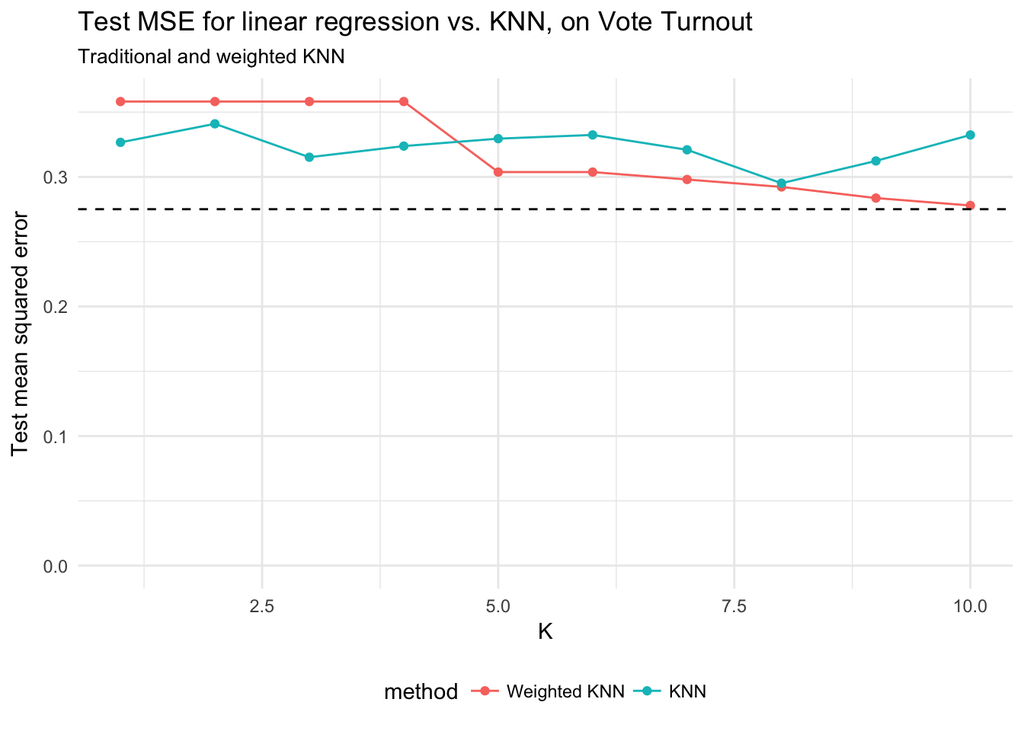

```
## The lowest MSE is:  0.278
```

According to the plot, with the increase of `k`, the weighted KNN models performs better than the traditional KNN model. The lowest test error rate of KNN models is produced by the model with `k = 10`, and the test MSE is 0.278.

### 4. Comparison

```
##
## Parameter tuning of 'svm':
##
## - sampling method: 10-fold cross validation
##
## - best parameters:
##  cost
##   100
##
## - best performance: 0.258
##
## - Detailed performance results:
##    cost error dispersion
## 1 1e-03 0.281     0.0381
## 2 1e-02 0.263     0.0382
## 3 1e-01 0.259     0.0378
## 4 1e+00 0.258     0.0377
## 5 5e+00 0.258     0.0377
## 6 1e+01 0.258     0.0377
## 7 1e+02 0.258     0.0377
```

```
##
## Call:
## best.tune(method = svm, train.x = vote96 ~ ., data = as_tibble(mh_split$train),
##     ranges = list(cost = c(0.001, 0.01, 0.1, 1, 5, 10, 100)),
##     kernel = "linear")
##
##
## Parameters:
##    SVM-Type:  eps-regression
##  SVM-Kernel:  linear
##        cost:  100
##       gamma:  0.143
##     epsilon:  0.1
##
##
## Number of Support Vectors:  574
```

```
## The test error rate of the best KNN model is:  0.295
```

```
## The test error rate of the best wKNN model is:  0.278
```

```
## The test error rate of equivalent logistic regression model is:  0.275
```

```
## The test error rate of equivalent decision tree is:  0.304
```

```
## The test error rate of equivalent boosting method is:  0.287
```

```
## The test error rate of equivalent random forest is:  0.312
```

```
## The test error rate of equivalent SVM is:  0.258
```

## Part 3: Colleges

In the `College` dataset, only the variable `Private` is a factor variable. And it prevents the PCA analysis from running. So I set it as a numeric variable and test whether it is strongly correlated with other variables. It turns out that `Private is not strongly correlated with other variables. However, I could not delete variables or data at will, so I still keep it in the model.

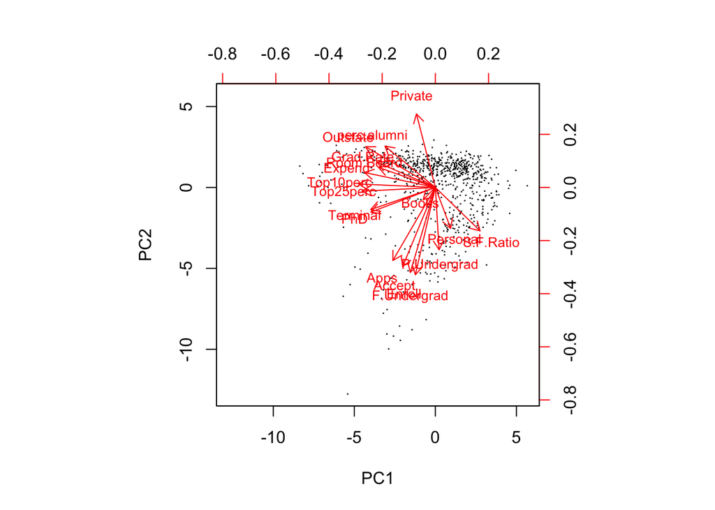

```
##                 PC1     PC2      PC3     PC4     PC5      PC6       PC7
## Private     -0.0890  0.3459 -0.15139 -0.2311  0.0443 -0.03145  0.178345
## Apps        -0.1996 -0.3436 -0.00482 -0.3050 -0.0230 -0.00862 -0.061047
## Accept      -0.1538 -0.3726  0.02535 -0.3175  0.0314  0.01307 -0.015474
## Enroll      -0.1178 -0.3997  0.02758 -0.2048 -0.0657 -0.04306 -0.008237
## Top10perc   -0.3603  0.0162 -0.00468  0.1075 -0.3882 -0.05992 -0.144406
## Top25perc   -0.3448 -0.0177  0.05895  0.1463 -0.4098  0.02061 -0.079889
## F.Undergrad -0.0941 -0.4107  0.01681 -0.1430 -0.0466 -0.04574  0.000282
## P.Undergrad  0.0175 -0.2931 -0.14937  0.0978  0.3280 -0.19678  0.162965
## Outstate    -0.3277  0.1915 -0.06636 -0.1288  0.2033 -0.02030  0.094948
## Room.Board  -0.2665  0.0940 -0.18211 -0.1824  0.5263  0.18303  0.145142
## Books       -0.0572 -0.0573 -0.66231  0.0893 -0.1586  0.64831 -0.141371
## Personal     0.0719 -0.1928 -0.46956  0.2906 -0.1880 -0.34706  0.609167
## PhD         -0.3033 -0.1162  0.20849  0.4646  0.2059  0.07189  0.031347
## Terminal    -0.3039 -0.1042  0.14672  0.4604  0.2656  0.13832  0.003847
## S.F.Ratio    0.2103 -0.2044  0.29225  0.0749 -0.0515  0.46937  0.275797
## perc.alumni -0.2367  0.1941  0.15944 -0.0100 -0.2151 -0.05166  0.286361
## Expend      -0.3330  0.0703 -0.21732 -0.0072  0.0571 -0.28447 -0.280168
## Grad.Rate   -0.2731  0.1178  0.17262 -0.2682 -0.1412  0.22185  0.501653
##                  PC8     PC9    PC10    PC11     PC12    PC13      PC14
## Private     -0.03231  0.0850 -0.2596  0.6798 -0.24569  0.4006 -1.01e-02
## Apps         0.09918 -0.0841 -0.0581 -0.0104 -0.04181  0.0374  5.95e-01
## Accept       0.05423 -0.1653 -0.0895  0.1426 -0.00455 -0.0736  2.93e-01
## Enroll      -0.06326 -0.1168 -0.0741  0.1058  0.03426  0.0591 -4.46e-01
## Top10perc    0.09714  0.3557 -0.0594 -0.0221  0.01518  0.0444  9.19e-05
## Top25perc    0.07806  0.4224 -0.0436  0.1382  0.23123 -0.0998  2.38e-02
## F.Undergrad -0.08393 -0.0498 -0.0504  0.0784  0.06250  0.0697 -5.25e-01
## P.Undergrad -0.56989  0.5432  0.2295  0.0451 -0.12114 -0.0228  1.26e-01
## Outstate     0.00412 -0.0114 -0.1973  0.0643 -0.25544 -0.8037 -1.28e-01
## Room.Board   0.24867  0.2442 -0.1899 -0.2808  0.48583  0.2014 -7.23e-02
## Books       -0.22503 -0.1333  0.0758  0.0204 -0.03719 -0.0249  1.18e-02
## Personal     0.30143 -0.1216 -0.1169 -0.0468  0.02038 -0.0379  4.01e-02
## PhD          0.07055 -0.1629  0.0560  0.1705 -0.09081  0.1172  1.25e-01
## Terminal     0.00463 -0.2332  0.0212  0.1784  0.01067  0.0544 -5.91e-02
## S.F.Ratio    0.09450  0.2845 -0.4477 -0.2162 -0.42475  0.0584 -1.92e-02
## perc.alumni -0.64039 -0.2905 -0.3463 -0.2600  0.21823  0.0916  1.03e-01
## Expend       0.03757 -0.0562 -0.0330 -0.4550 -0.54829  0.2993 -9.86e-02
## Grad.Rate    0.07773 -0.0226  0.6600 -0.1031 -0.15593  0.0729 -7.00e-02
##                PC15     PC16      PC17      PC18
## Private     -0.0232 -0.00537 -0.044796  0.007795
## Apps        -0.0807  0.13375 -0.458603  0.363283
## Accept      -0.0333 -0.14635  0.512188 -0.547462
## Enroll       0.0815  0.02848  0.403907  0.607174
## Top10perc    0.1062  0.69742  0.148018 -0.146308
## Top25perc   -0.1487 -0.61690 -0.050194  0.080606
## F.Undergrad  0.0534  0.00984 -0.569725 -0.408938
## P.Undergrad -0.0196  0.02068  0.050648  0.008963
## Outstate     0.0572  0.04195 -0.078622  0.048023
## Room.Board   0.0560  0.00351  0.028890  0.000368
## Books        0.0677 -0.00927 -0.001728  0.000603
## Personal    -0.0266 -0.00304  0.012911 -0.001211
## PhD          0.6864 -0.11269 -0.035842  0.015128
## Terminal    -0.6746  0.15786  0.020277  0.007143
## S.F.Ratio   -0.0449 -0.02172  0.014827 -0.001297
## perc.alumni  0.0268 -0.00815 -0.000483 -0.019705
## Expend      -0.0809 -0.22876  0.038317 -0.034863
## Grad.Rate   -0.0372 -0.00327  0.006996 -0.013507
```

According to the table, the variables `Top10perc`, `Top25perc`, `Outstate`, `PhD`, `Terminal` and `Expend` are highly correlated. Their vectors’ directions and their length are very similar, all between (0.30, 0.37), on the first principal component dimension. On the second principal component, the strongly correlated variables are `Private`, `Apps`, `Accept`, `Enroll`, `F.Undergrad` and `P.Undergrad`. Their vectors’ length are very similar. It makes sense. The first principal component represents the quality of the colleges (expenditure, and popularity are also explanatory factors of quality :)). And the second principal component represents how large the population is.

## Part 4: Clustering states

The categorical variable `State` is used to mark the data source, which is not relevant to modelling analysis. But it is still kept for labels of plot.

### 1. PCA

The PCA is performed. See the plot below for its observations on the first and second principal components.

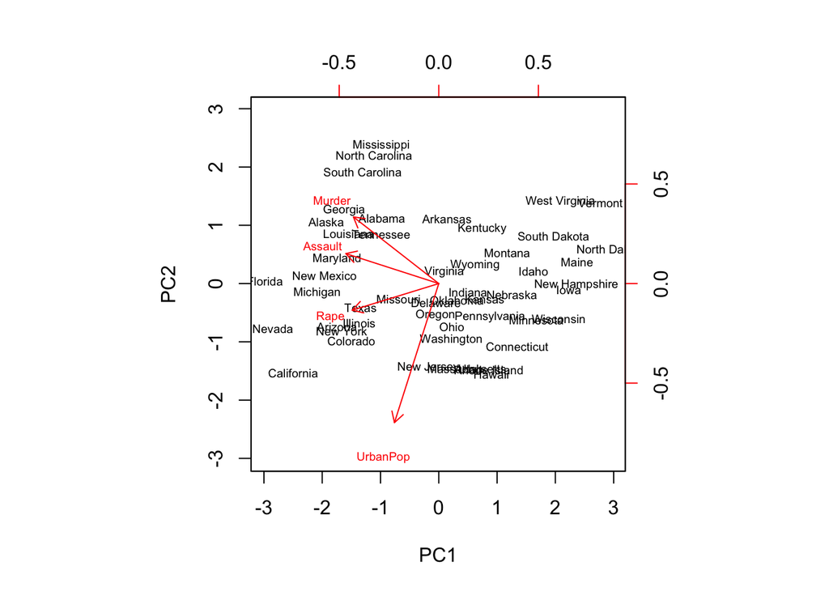

```
##             PC1    PC2    PC3    PC4
## Murder   -0.536  0.418 -0.341  0.649
## Assault  -0.583  0.188 -0.268 -0.743
## UrbanPop -0.278 -0.873 -0.378  0.134
## Rape     -0.543 -0.167  0.818  0.089
```

The first principal component is mainly formed by `Murder`, `Assault` and `Rape`, which represents crime arrests of the data. And the second principal component is mainly formed by `UrbanPop`, which represents crime rate calculated by arrests over urban population. The PCA performs pretty well here.

### 2. K-means clustering with K = 2

The K-means clustering with K = 2 is performed as required. See the plot for the observations on the first and second principal components.

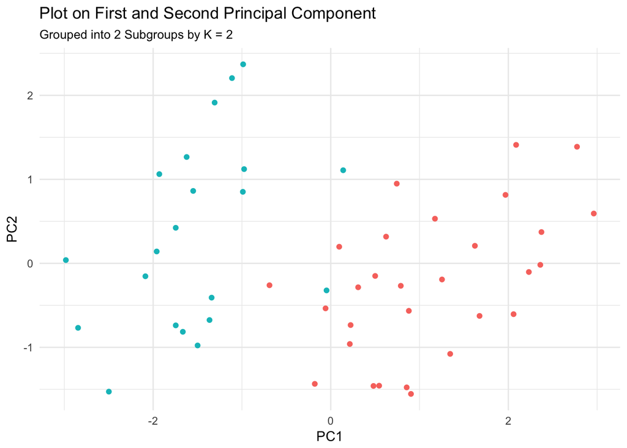

### 3. K-means clustering with K = 4

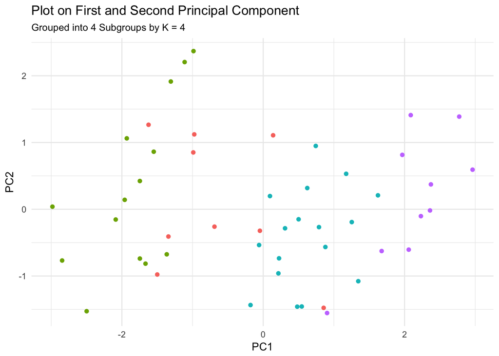

The states are clustered into 4 subgroups. It seems that their group membership is defined by the first principal component, rather than the second principal component. They could be defined as “most dangerous”, “dangerous”, “safe” and “most safe” states.

### 4. K-means clustering with K = 3

[figure not shown]

The K-means clustring with K = 3 still group the states based on their performance on the first principal component. But the differences among groups are not very clear.

### 5. K-means clustering with K = 3 on the first two principal components score vectors

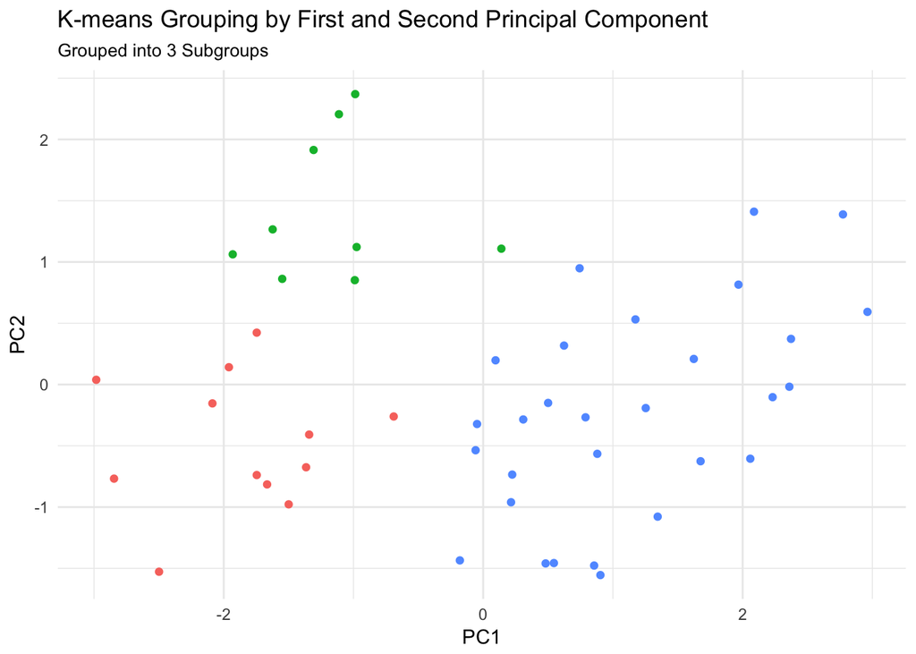

Now we could happily defined the states as “dangerous”, “neutral” and “safe” states. Differences among the three groups now are much more clear.

### 6. Hierarchical clustering

Hierarchical clustering is performed with complete linkage and Eudclidean distance, as is required.

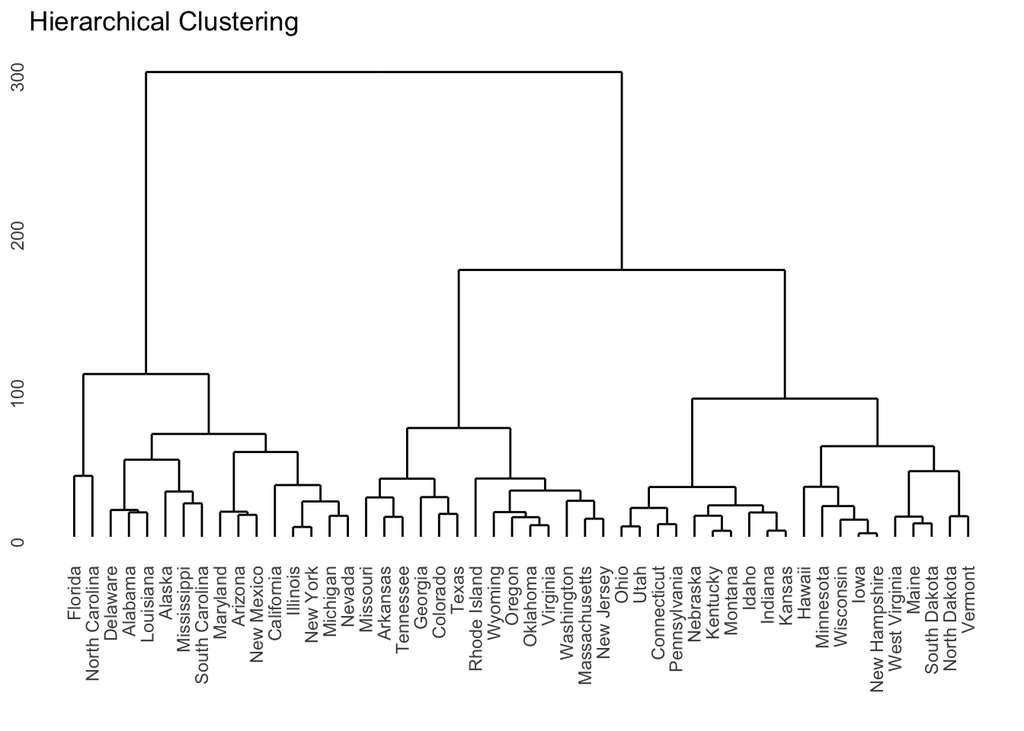

We should read the dendrogram from the bottom-up. Some states fuse together near the bottom, which means they are similar, like Florida and North Carolina. States fuse together on a higher level are less similar, like Ohio and Vermont. States fuse on the top would be the most unlike, like Florida and Vermont.

### 7. Cut the dendrogram

The dendrogram is cut at `height = 150`, because it appears on the plot of `question 6` that it could be cut into three distince clusters at approximately this height.

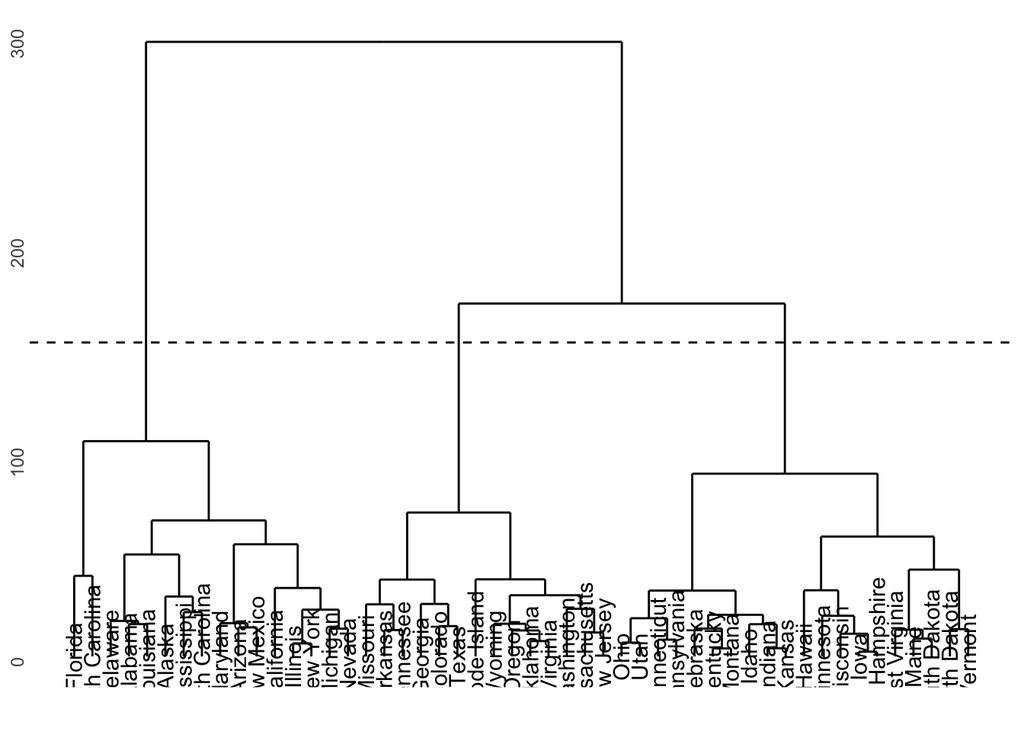

According to the dendrogram, for example, the Florida and New Mexico belong to the same cluster. For another example, Utah and Vermont belong to the same cluster. All states within the same branch defined by the cut belong to the same cluster.

### 8. Hierarchically cluster with scaling the variables to have standard deviation 1

The variables are scaled to have standard deviation 1, as is required. See the plot below for the new dendrogram.

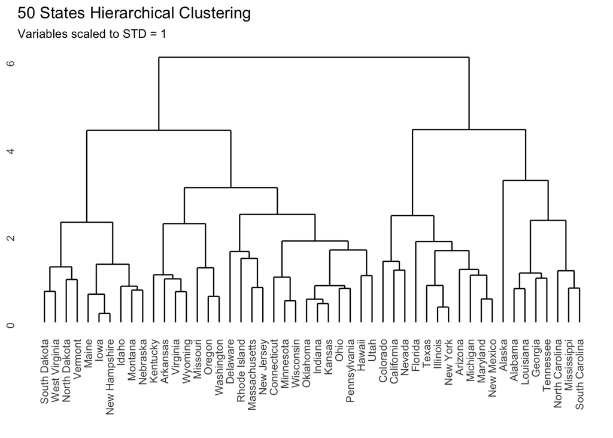

According to the plot, the scaling process gives equal weight to each variables. So if we cut the dendrogram around 4, we would get 4 clusters. And if we cut the dendrogram around 5, we would get 2 clusters. Generally, it depends on the need of research, whether the variables should be scaled before the inter-observation dissimilarities are computed. However, in this case, I think it would be more appropriate not to scale the variables before the inter-observation dissimilarities are computed. Because three of these variables are describing how much crime arrests the states have, while the remaining one is describing the relative pattern.